# dtas-5301-COVID-project

Andrew M.

2024-12-10

## Introduction

The data used in this project consist of the COVID-19 cases and deaths from the John Hopkins Coronavirus Resource Center. The data are publicly available at their Github page: https://github.com/CSSEGISandData/COVID-19/tree/master. Data collection ceased on March 10, 2023, so these data reflect only the time from January 22, 2020 until the end of data collection. In this report, I am interested in questions relating to the early spread of COVID-19 before the introduction of vaccines. Since the vaccine was approved in December 2020, I primarily constrain my analysis to the data collected during 2020.

## Importing COVID-19 Data

This script fetches the raw data from the Johns Hopkins Github repository.

```r
url_root <- "https://raw.githubusercontent.com/CSSEGISandData/COVID-19/refs/heads/master/csse_covid_19_data/csse_covid_19_time_series/"
file_names <-
  c("time_series_covid19_confirmed_global.csv",
    "time_series_covid19_deaths_global.csv",
    "time_series_covid19_confirmed_US.csv",
    "time_series_covid19_deaths_US.csv")
urls <- str_c(url_root, file_names)
global_cases <- read_csv(urls[1], show_col_types = FALSE)
global_deaths <- read_csv(urls[2], show_col_types = FALSE)
US_cases <- read_csv(urls[3], show_col_types = FALSE)
US_deaths <- read_csv(urls[4], show_col_types = FALSE)

uid_lookup_url <- "https://raw.githubusercontent.com/CSSEGISandData/COVID-19/refs/heads/master/csse_covid_19_data/UID_ISO_FIPS_LookUp_Table.csv"
uid <- read_csv(uid_lookup_url, show_col_types = FALSE)
```

## Tidying the data

For my first visualization, I want to compare the United States and Canada. So I clean up the global data to only include the rows from Canada.

```r
global_cases_tidied <- global_cases %>%
  pivot_longer(cols = -c('Province/State', 'Country/Region', Lat, Long), names_to = "date", values_to = "cases") %>%
  rename(Province_State = `Province/State`, Country_Region = `Country/Region`) %>%
  select(-c(Lat, Long))
global_deaths_tidied <- global_deaths %>%
  pivot_longer(cols = -c('Province/State', 'Country/Region', Lat, Long), names_to = "date", values_to = "deaths") %>%
  rename(Province_State = `Province/State`, Country_Region = `Country/Region`) %>%
  select(-c(Lat, Long))
global_cases_and_deaths <- global_cases_tidied %>%
  full_join(global_deaths_tidied) %>%
  mutate(date = mdy(date)) %>%
  filter(cases > 0) %>%
  left_join(uid, by = c("Province_State", "Country_Region")) %>%
  select(-c(UID, FIPS)) %>%
  select(Province_State, Country_Region, date, cases, deaths, Population)
Canada_cases_and_deaths <- global_cases_and_deaths %>%
  filter(`Country_Region` == "Canada") %>%
  unite("Combined_Key", c(`Province_State`, `Country_Region`), sep = ", ", na.rm = TRUE, remove = FALSE)
US_cases_tidied <- US_cases %>%
  pivot_longer(cols = -(UID:Combined_Key), names_to = "date", values_to = "cases") %>%
  select(Province_State:cases) %>%
  select(-c(Lat, Long_))
US_deaths_tidied <- US_deaths %>%
  pivot_longer(cols = -(UID:Population), names_to = "date", values_to = "deaths") %>%
  select(Province_State:deaths) %>%
  select(-c(Lat, Long_, Population))
US_cases_and_deaths <- US_cases_tidied %>%
  full_join(US_deaths_tidied) %>%
  mutate(date = mdy(date)) %>%
  filter(cases > 0)
```

## Early spread of COVID-19 in the United States versus Canada

I first want to investigate the trends in the spread of the virus during the initial period of the virus. For this investigation, I’m going to only consider data from the year 2020, before the introduction of widespread vaccination. I compare the United States and Canada simply as a baseline measure of two highly-developed North America nations with populations that are spread between urban and rural areas.

The purpose of this question is to begin to drill down into questions such as, which country had a more effective response; what other variables should we consider when comparing two countries; or was the response of one country even more effective than the other?

Looking at the figure, we can immediately see that the pattern of growth in the United States is much sharper than in Canada. Specifically, cases grew exponentially at the end of the year. After the summer of social distancing, individuals in the United States were possibility more willing to return to normal activities in the fall, e.g. some children even went back to school. A further analysis I would like to see is whether individual states had the same or different trends as the country as a whole.

Population figures for 2020 were retrieved from: https://databank.worldbank.org/source/population-estimates-and-projections/

```r
Canada_2020_population <- 38028638
Canada_2020_cases <- Canada_cases_and_deaths %>%
  filter(between(date, as.Date('2020-01-01'), as.Date('2020-12-31'))) %>%
  group_by(date, Country_Region) %>%
  summarize(cases = sum(cases), deaths = sum(deaths), population = Canada_2020_population) %>%
  mutate(cases_per_mill = cases * 1000000 / population)
US_2020_population <- 331526933
US_2020_cases <- US_cases_and_deaths %>%
  filter(between(date, as.Date('2020-01-01'), as.Date('2020-12-31'))) %>%
  group_by(date, Country_Region) %>%
  summarize(cases = sum(cases), deaths = sum(deaths), population = US_2020_population) %>%
  mutate(cases_per_mill = cases * 1000000 / population)
```

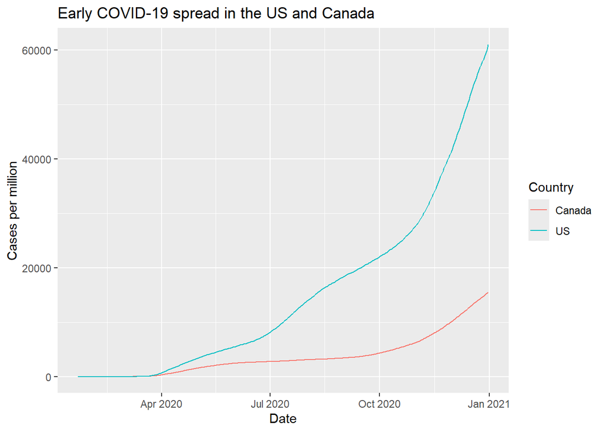

```r
joined_US_and_Canada <- bind_rows(Canada_2020_cases, US_2020_cases)
plot <- ggplot(joined_US_and_Canada, aes(x = date, y = cases_per_mill, color = Country_Region)) +
  geom_line() +
  labs(x = "Date", y = "Cases per million", title = "Early COVID-19 spread in the US and Canada", color = "Country")
plot
```

The purpose of this visualization is to be able to see the trends within larger buckets of data. For example, in months where the spread of COVID-19 was lower than the previous month, we can begin to investigate the impact of specific policies, procedures, or other events that changed the rate of spread of COVID-19. New York is the clear outlier in terms of both the early explosion of COVID-19 within the state and the more controlled spread during the summer of 2020. Nevertheless, during the fall of 2020, New York begins to exhibit similar trends as the other three states.

Population figures for 2020 were retrieved from: https://www.census.gov/library/visualizations/interactive/2020-population-and-housing-state-data.html

```r
California_pop <- 39538223
Florida_pop <- 21538187
New_York_pop <- 20201249
Texas_pop <- 29145505
US_2020_cases_by_month <- US_cases_and_deaths %>%
  filter(Province_State == c("California", "Florida", "New York", "Texas")) %>%
  filter(between(date, as.Date('2020-01-01'), as.Date('2020-12-31'))) %>%
  select(c(date, Province_State, cases)) %>%
  group_by(Province_State, month(date)) %>%
  summarize(cases = sum(cases)) %>%
  mutate(new_cases = cases - lag(cases, n=1)) %>%
  mutate(new_cases = coalesce(new_cases, cases)) %>%
  mutate(population = case_when(
    Province_State == "California" ~ California_pop,
    Province_State == "Florida" ~ Florida_pop,
    Province_State == "New York" ~ New_York_pop,
    Province_State == "Texas" ~ Texas_pop
  )) %>%
  mutate(new_cases_per_mill = new_cases * 1000000 / population)
```

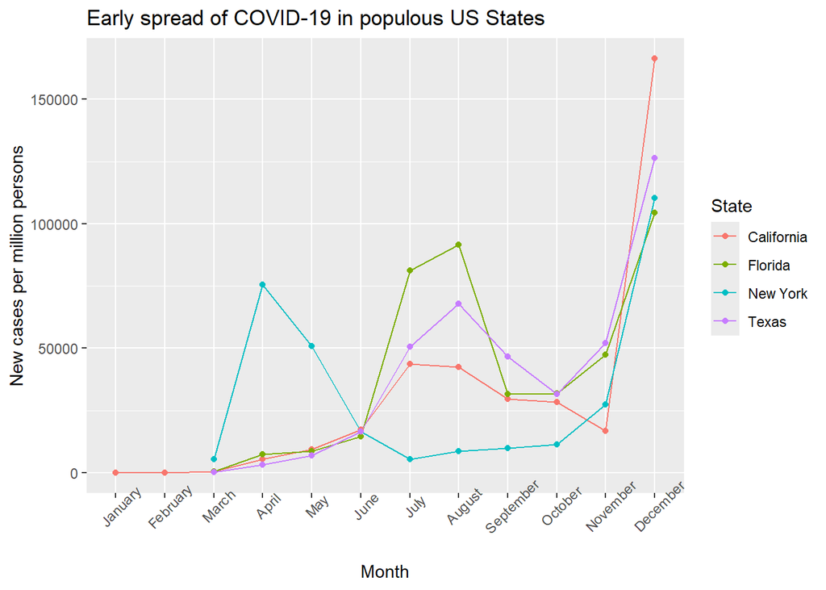

```r
colnames(US_2020_cases_by_month)[colnames(US_2020_cases_by_month) == 'month(date)'] <- 'month'
plot <- ggplot(US_2020_cases_by_month, aes(x = factor(month), y = new_cases_per_mill, group =  Province_State,color = Province_State)) +
  geom_line() +
  geom_point() +
  theme(axis.text.x = element_text(angle = 45)) +
  scale_x_discrete(labels = c("January", "February", "March", "April", "May", "June", "July", "August", "September", "October", "November", "December"))  +
  labs(x = "Month", y = "New cases per million persons", title = "Early spread of COVID-19 in populous US States", color = "State")
plot
```

## Modeling spread of COVID-19 in the US after vaccine introduction In this model, I want to compare the trends of spread of COVID-19 in the US during 2020 and 2021. Vaccines were introduced in December 2020, so I want to see if we can visualize how the introduction of vaccines impacted the trend of the spread of COVID-19.

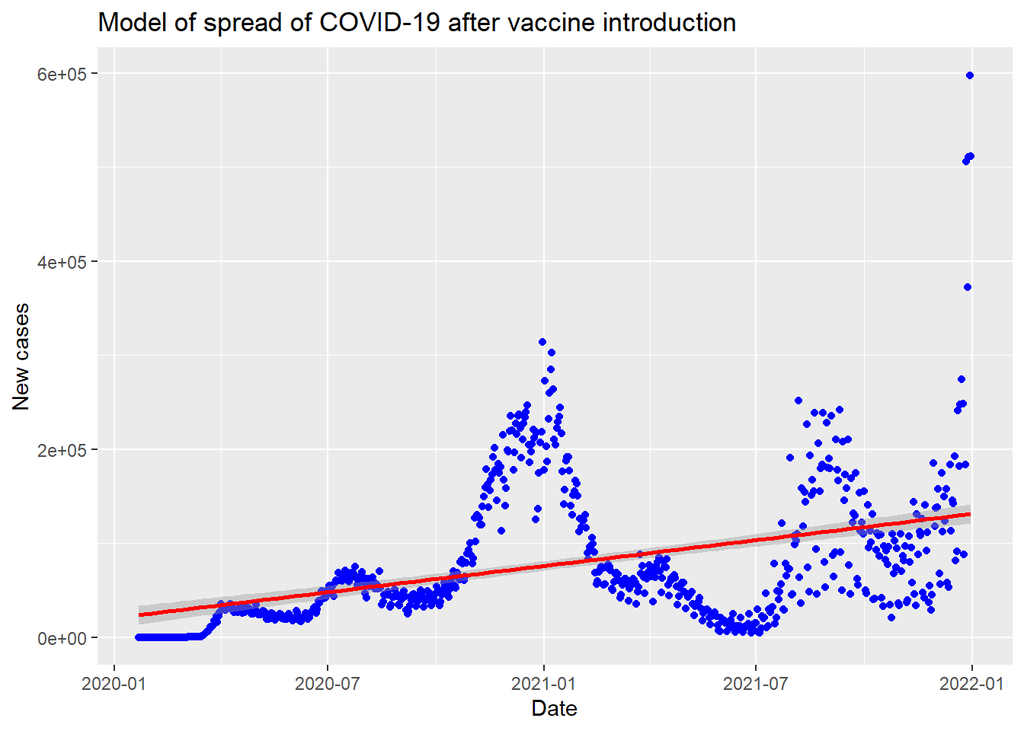

```r
US_2020_2021_cases <- US_cases_and_deaths %>%
  filter(between(date, as.Date('2020-01-01'), as.Date('2021-12-31'))) %>%
  group_by(date, Country_Region) %>%
  summarize(cases = sum(cases), deaths = sum(deaths), .groups = 'drop')
US_2020_2021_cases$new_cases <- ave(US_2020_2021_cases$cases, FUN = function(x) c(NA, diff(x)))
US_2020_2021_cases <- US_2020_2021_cases %>%
  mutate(new_cases = replace_na(new_cases, 0))
mod_plot <- US_2020_2021_cases %>% ggplot(aes(x = date, y = new_cases)) +
  geom_point(color = "blue") +
  geom_smooth(formula = y ~ x, method = "lm", color = "red") +
  labs(x = "Date", y = "New cases", title = "Model of spread of COVID-19 after vaccine introduction")
mod_plot
```

## Conclusions and limitations Looking at how the virus spread across the early years of COVID-19 reveals a number of interesting avenues for further exploration. Limitations of my analysis include a number of factors: primarily looking at the United States, relying on only a single data source for information, and the presumed under-reporting of cases as at-home tests became more widely available.